# Moving Average Model

# 2. Example: MA(3)

$$X_t = e_t - \theta_1 e_{t-1} - \theta_2 e_{t-2} - \theta_3 e_{t-3}$$

$$\gamma(h) =
\left\{
\begin{array}{ll}
\sigma^2 (1+\theta_1^2 +\theta_2^2 + \theta_3^2 ) & \mbox{ if } h=0 \\
\sigma^2 (-\theta_1 + \theta_2 \theta_1 + \theta_3 \theta_2 ) & \mbox{ if } h=1 \\
\sigma^2 (-\theta_2 + \theta_3 \theta_1 ) & \mbox{ if } h=2 \\
\sigma^2 (-\theta_3 ) & \mbox{ if } h=3 \\
0 & \mbox{ if } |h|> \\
\end{array} \right.$$

$$\rho(h) = \gamma(h) / \gamma(0)$$

Watch the Sign!

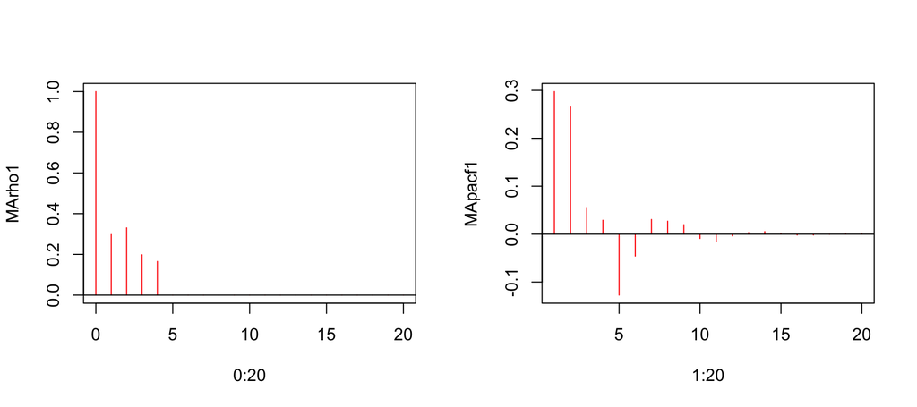

```r
#   [Cryer]'s sign convention is (1-phi B) Y_t = (1-theta) e_t.
#   [Brockwell]'s             is (1-phi B) Y_t = (1+theta) e_t.
#
#   For AR(1) (1-.5 B) Y_t = e_t,          ACF should be all positive.
#             (1+.5 B) Y_t = e_t,          ACF should be alternating in sign.
#
#   For MA(1)          Y_t = (1-.5 B) e_t  ACF at lag 1 should be negative
#                      Y_t = (1+.5 B) e_t  ACF at lag 1 should be positive

#--- Theoretical ACF and PACF of MA ---
#     ARMAacf() uses  sign of MA parameters like [Brockwell]:  Y_t = (1+theta B) e_t
    Theta = c(.2,  .3, .2,  .2)

    MArho1 <- ARMAacf(ma = Theta, lag.max=20, pacf=FALSE)
    MApacf1<- ARMAacf(ma = Theta, lag.max=20, pacf=TRUE)

    layout(matrix(1:2, 1,2))
    plot(0:20, MArho1, type="h", col="red");   abline(h=0)
    plot(1:20, MApacf1, type="h", col="red");   abline(h=0)
```

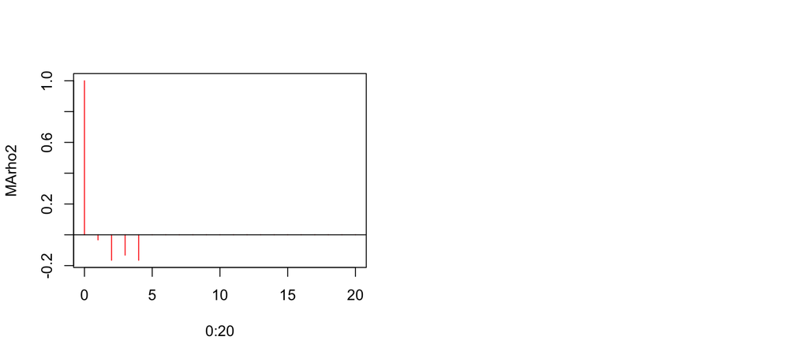

```r
#--- Theoretical ACVF of MA
#
#   tacvfARMA() uses sign of MA parameters like [Cryer]:  Y_t = (1 - theta B) e_t
#

  library(ltsa)

  MAgam2 <- tacvfARMA(theta= c(.2, .3, .2, .2), maxLag=20, sigma2=1)  #- Theoretical ACVF
  MArho2 <- MAgam2/MAgam2[1]                                          #- Theoretical ACF

  plot(0:20, MArho2, type="h", col="red");   abline(h=0)
```

## Simulation: MA(q)

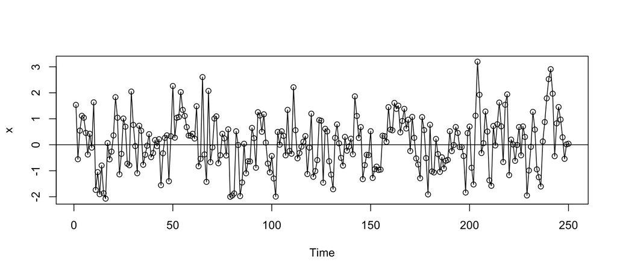

```r
  T1 = c(.5)
  T2 = c(.2, -.3, .2, -.2)
  T3 = c(.2,  .3, .2,  .2)
  T4 = c(-.2,  -.3, -.2,  -.2)

  Theta = T1

  # arima.sim() uses sign of MA parameters like [Brockwell]:  Y_t = (1+theta B) e_t

  x  <- arima.sim( list(ma = c(0.5) ), n=250    )
  MArho1 <- ARMAacf(ma = Theta, lag.max=20, pacf=FALSE)
  MApacf1<- ARMAacf(ma = Theta, lag.max=20, pacf=TRUE)

  plot(x, type="o");  abline(h=0)
```

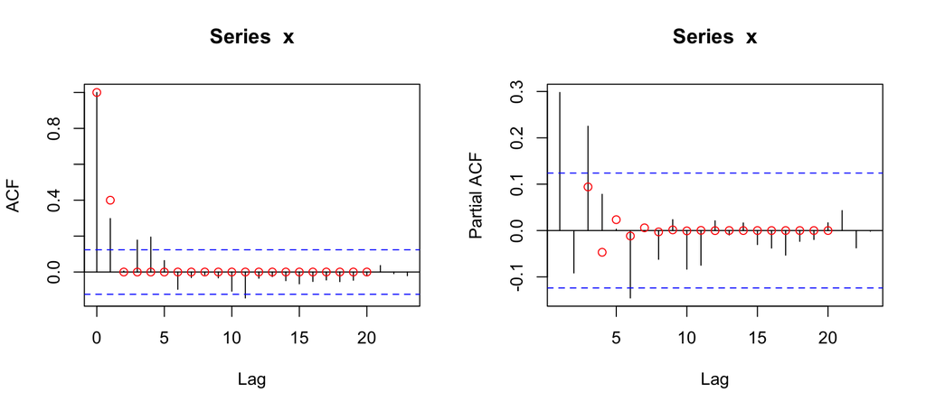

```r
  layout(matrix(1:2, 1, 2) )
  acf(x);    lines(0:20, MArho1,  type="p", col="red")
  pacf(x);   lines(1:20, MApacf1, type="p", col="red")
```

```r
  layout(1)
```

## Characteristics of MA(q)

- ACF cuts off at $q$
- PACF tails off

# 3. Invertible Representation of MA(q)

- Suppose we have MA(1) model **(watch the sign!)**
  $$X_t = e_t + \theta_1 e_{t-1}$$
  This is already a causal representation.
- We can rewrite the equation and get
  $$X_t - \theta_1 e_{t-1} \hspace3mm = \hspace3mm e_t.$$
- That means we can do the same for $X_{t-1}$, and write
  $$X_{t-1} - \theta_1 e_{t-2} \hspace3mm = \hspace3mm e_{t-1}$$
  We can substitute this into $e_{t-1}$ above.
- Substituting this expression of $e_{t-1}$ into the first equation,
  $$X_t - \theta_1 e_{t-1} \hspace3mm = \hspace3mm e_t. \\\\
  X_t - \theta_1 \big(X_{t-1} - \theta_1 e_{t-2} \big) \hspace3mm = \hspace3mm e_t \\ \\
  X_t - \theta_1 X_{t-1} - \theta_1^2 e_{t-2} \hspace3mm = \hspace3mm e_t$$
- Repeat this $n$ times, we get
  $$X_t - \theta_1 X_{t-1} - \cdots - \theta_1^{n-1} X_{t-n+1} - \theta_1^n e_{t-n} \hspace3mm = \hspace3mm e_t$$
  If $|\theta_1|<1$, then we can write
  $$e_t \hspace3mm = \hspace3mm \sum_{i=0}^\infty \theta_1^i \, X_{t-i}$$
  This is called invertible representation.
- $$e_t \hspace3mm = \hspace3mm \sum_{i=0}^\infty \pi_i X_{t-i} \\ \\
  \hspace3mm = \hspace3mm (\pi_0 + \pi_1 B + \pi_2 B^2 + \pi_3 B^3 + \cdots ) \, X_{t} \\ \\
  \hspace3mm = \hspace3mm \Pi(B) \, X_{t}$$
- So for our MA($q$) model
  $$X_t \hspace3mm = \hspace3mm \Theta(B) e_t \\ \\
  \Pi(B) \, X_{t} \hspace3mm = \hspace3mm e_t$$
- Very similar to causal representation in AR($p$), we have identity,
  $$\Pi(z) \hspace3mm = \hspace3mm \frac{1}{\Theta(z)}$$
  $$(\pi_0 + \pi_1 z + \pi_2 z^2 + \pi_3 z^3 + \cdots ) \hspace3mm = \hspace3mm
  \frac{1}{(1+\theta_1 z + \theta_2 z^2 + \cdots + \theta_q z^q)}$$
- We can calculate coefficients by moving all the polynomials to the left and matching
  $$(1-\theta_1 z - \theta_2 z^2 - \cdots - \theta_q z^q)(\pi_0 + \pi_1 z + \pi_2 z^2 + \pi_3 z^3 + \cdots ) \hspace3mm = \hspace3mm
  1$$
- For example, if we have MA(1),
  $$(1-\theta_1 z )(\pi_0 + \pi_1 z + \pi_2 z^2 + \pi_3 z^3 + \cdots ) \hspace3mm = \hspace3mm 1$$
- To find out the coeffeicnets $\pi_i$, we can match the order of $z$.
  $$\begin{align}
  \pi_0 &= \hspace3mm 1 \hspace15mm (\mbox{ coefficient without $z$ })\\
  -\theta_1 \pi_0 + \pi_1 &= \hspace3mm 0 \hspace15mm (\mbox{ coefficient of $z$})\\
  -\theta_1 \pi_1 + \pi_2 &= \hspace3mm 0 \hspace15mm (\mbox{ coefficient of $z^2$})\\
  -\theta_1 \pi_2 + \pi_3 &= \hspace3mm 0 \hspace15mm (\mbox{ coefficient of $z^3$})\\
  &\vdots&
  \end{align}$$

  $$\begin{align}
  \pi_0 &= \hspace3mm 1 \\
  \pi_1 &= \hspace3mm \theta_1 \pi_0 \\
  \pi_2 &= \hspace3mm \theta_1 \pi_1 \\
  \pi_3 &= \hspace3mm \theta_1 \pi_2 \\
  &\vdots&
  \end{align}$$

  $$\begin{align}
  \pi_0 &= \hspace3mm 1 \\
  \pi_1 &= \hspace3mm \theta_1 \\
  \pi_2 &= \hspace3mm \theta_1^2\\
  \pi_3 &= \hspace3mm \theta_1^3\\
  &\vdots&
  \end{align}$$

## Invertible Representation of MA(1)

- Now we get invertible representation for MA(1),
  $$e_t \hspace3mm = \hspace3mm \sum_{i=0}^\infty \pi_i \, X_{t-i}
  = \sum_{i=0}^\infty \theta_1^i \, X_{t-i}.$$
- To write the today’s error (innovation) $e_t$, we need infinetely many past observation $X_{t-i}$.
- When can we do this?

## Invertibility Condition

- If all roots of characteristic polynomial
  $$\Theta(z) = 1 + \theta_1 z + \theta_2 z^2 + \cdots + \theta_q z^q$$
  is outside of the unit circle, then MA($q$) admits a invertible representation.
- Same as causal condition in AR($p$).
- Watch the sign! We have same sign as $\Phi(z)$ in AR($p$), because we started with Brockwell’s convention; $X_t = e_t + \theta_1 e_{t-1}$.
- We assume all MA($q$) we deal with are invertible.

# 4. Why Invertibility Condition is Important

## To Get Residual

- If we have MA(3) process,
  $$X_t = e_t -\hat \theta_1 e_{t-1} -\hat \theta_2 e_{t-2} -\hat \theta_3 e_{t-3}$$
  with estimated parameter $\hat \theta_i$, we want to get residuals $\hat e_t$, and check their randomness.
- In AR($p$), this was intuitive. e.g. if we had AR(2), residual was
  $$X_t - \hat \phi_1 X_{t-1} - \hat \phi_2 X_{t-2} = \hat e_t$$
- In MA($q$), we must use invertible expression,
  $$\hat e_t = \hat \pi_0 X_t + \hat \pi_1 X_{t-1} + \hat \pi_2 X_{t-2} + \cdots$$

## And To Get Predictor

- The best 1-step linear predictor of AR(3) model was
  $$\hat X(1) \hspace3mm = \hspace3mm \phi_1 X_n + \phi_2 X_{n-1} + \phi_3 X_{n-2}.$$
  This was intuitive since AR(3) model says
  $$X_{t+1} \hspace3mm = \hspace3mm \phi_1 X_n + \phi_2 X_{n-1} + \phi_3 X_{n-2} + e_{t+1}.$$
  Would the same happens for MA(q)?
- Take MA(1). We have
  $$X_{t+1} \hspace3mm = \hspace3mm e_{t+1} + \theta_1 e_t .$$
  Since $e_{t+1}$ is uncorrelated new innovation (error) with mean 0, we would guess that the best predictor may look like
  $$\hat X(1) \hspace3mm = \hspace3mm - \theta_1 e_t .$$
- $e_t$ is yesterday’s innovation. It has already been generated, but it’s not observable. Then we can replace it with our invertible representation,
  $$\hat X(1)
  \hspace3mm = \hspace3mm - \theta_1 \hat e_t,
  \hspace15mm \hat e_t = \sum_{i=1}^n \pi_i X_{t-i}.$$
- For MA(1), we know $\pi_i$ are
  $$\hat X(1)
  \hspace3mm = \hspace3mm - \theta_1 \big(\pi_0 X_t + \pi_1 X_{t-1} + \pi_2 X_{t-2} + \cdots + \pi_{t-1} X_{1} \big) \\\\
  \hspace3mm = \hspace3mm - \theta_1 \big(X_t + \theta_1 X_{t-1} + \theta_1^2 X_{t-2} + \cdots + \theta_1^{t-1} X_{1} \big) \\\\$$
  This actually turns out to be best linear predictor for $X_{t+1}$. (minimum prediction MSE which is equal to $\sigma^2$.)

# 5. Predicting MA(q) Model

- Consider MA(4) model:

  $$X_t \hspace3mm = \hspace3mm
  e_t - \theta_1 e_{t-1} - \theta_2 e_{t-2} - \theta_3 e_{t-3} - \theta_4 e_{t-4}$$
- Tomorrow’s value will be generated as

  $$X_{t+1} \hspace3mm = \hspace3mm
  e_{t+1} - \theta_1 e_{t} - \theta_2 e_{t-1} - \theta_3 e_{t-2} - \theta_4 e_{t-3}$$
- It turns out that best linear predictor of MA(4) model is

  $$\hat X(1) \hspace3mm = \hspace6mm - \theta_1 e_{t} - \theta_2 e_{t-1} - \theta_3 e_{t-2} - \theta_4 e_{t-3}$$
- In practice, we must use estimator for both $\theta$ and $e_t$,

  $$\hat X(1) \hspace3mm = \hspace6mm
  - \hat \theta_1 \hat e_{t-1} - \hat \theta_2 \hat e_{t-2}
  - \hat \theta_3 \hat e_{t-3} - \hat \theta_4 \hat e_{t-4}$$
  where residuals $\hat e_t$ are calculated using the invertible representation.
- 1-step predition MSE is the conditional variance

  $$E[(\hat X(1) - X_{t-1})^2] = V(e_t) = \sigma^2$$
- long-term h-step prediction is the mean

  $$\hat X(h) = E(X_{t+1}) = 0$$
- long-term h-step prediction MSE is the unconditional variance

  $$E[(\hat X(h) - X_{t+h})^2] = V(X_{t+h})$$

# Summary

[TS Class Web Page](https://nmimoto.github.io/477/index.html) – [R resource page](https://nmimoto.github.io/R/index.html)